# Complete Guide to Automatic Prompt Optimization in Python [wip]

Maxime Rivest

2025-07-27

*This tutorial is sponsored by Pixeltable*

As your AI systems become more widely used, you may start to feel the urge to measure and optimize the quality of your prompt(s) (the very foundation on which your entire system relies. I know I did). By the end of this course, you’ll understand exactly what world-class optimizers like DSPy do, how to use DSPy, and how to customize it for your specific needs (for example, optimizing with DSPy and then running the optimized prompt on your own system).

Our focus here is on prompt optimization. While dspy and its creators are world reknowned for prompt optimization this is not actually dspy’s focus. DSPy rather focuses on helping *you* building compound AI systems, that is: system where code, control flow, and one or many AI component or interleaved togehter. To build such system tuning (e.i. optimization) is important, thus dspy has very strong tooling to help you optimize prompts, but it’s a little bit ‘baked it’, as dspy does not promise to help you optimize prompt but rather optimize ai systems, as such it can feel a little be black boxy. I have made and I will make more tutorial on who to use DSPy to built compound AI systems and why you should lean into that paradigm as soon as you want to call an AI with code, but in this tutorial, we will focus on the prompt optimization.

This tutorial is in three parts, first we will build our own prompt optimizer, I find that there is no better way to really understand something then to build it ourselves, second we will look how easier and better we can do it using DSPy, and third we will look at how we can customize DSPy to leverage its prompt optimization capabilities while be able to take ‘leave’ dspy and take that optimized prompt with us.

Our task here will be to build an AI system that can extract information from pictures of receipts.

# Building a Simple Prompt Optimizer

Let’s start by building our own prompt optimizer, by hand! To optimize a prompt automatically we need a target, we need to know what is the intent of the system. Intent, can be specified in many way: 1) by example, with a goldset, 2) by a rubric or judge, 3) by instructions and/or 4) by stating the input/output. See [this post to read more about that](https://maximerivest.com/posts/on-building-ai-programs.html) to learn more. For now, we will build an optimizer that using (1) and (3) and in our code we will use the examples (1) to measure our progress. DSPy has optimizers that provides all 4 sources of intents to AI to optimize the system.

## The Task

Our task here will be to build an AI system that can extract information from pictures of receipts.

[figure not shown]

Example of Receipt

For instance, on the above receipt the after tax amount is 45.10 CAD but the before tax is not written it must be calculated as `45.10 − 1.96 − 3.91 = 39.23`

## Simple Extraction of One Receipt

### First API Call

**Installs and Connections**

We’ll use LiteLLM as our interface to the LLMs. While I rarely use LiteLLM on its own, here it will give us a provider-agnostic yet relatively barebones way to call LLMs.

First, we’ll set up LiteLLM and make sure we can call a model. In this tutorial, we’ll use Llama 4 Scout on Groq—it supports image inputs, and Groq’s hosting is both extremely fast and quite affordable.

For this section of the tutorial, we’ll be using LiteLLM and Pixeltable, so let’s start by installing them:

````markdown
```{python}
%pip install -qU litellm pixeltable
```
````

```python
import os
import re
import io
from pathlib import Path
import base64

from typing import Optional, Dict

from PIL import Image
from pydantic import BaseModel, field_validator
import litellm
import pixeltable as pxt
from pixeltable import func
```

Let’s test a connection to our chosen LLM and LiteLLM:

```python
from litellm.caching.caching import Cache
litellm.cache = Cache(type="disk")

response = litellm.completion(
  model="groq/meta-llama/llama-4-scout-17b-16e-instruct",
  messages=[{ "content": "Hello, how are you?","role": "user"}],
  api_key= os.environ["GROQ_API_KEY"] # this is not necessary but its to show you that you can provide you api key directly here
)
print(response.model_dump_json(indent=4))
```

```
{
    "id": "chatcmpl-aa65c96c-92e5-42c9-beb3-1f3eb121972a",
    "created": 1755090714,
    "model": "meta-llama/llama-4-scout-17b-16e-instruct",
    "object": "chat.completion",
    "system_fingerprint": "fp_cb546bdbdf",
    "choices": [
        {
            "finish_reason": "stop",
            "index": 0,
            "message": {
                "content": "Hello! I'm just a language model, I don't have feelings like humans do, but I'm functioning properly and ready to help you with any questions or tasks you have! How can I assist you today?",
                "role": "assistant",
                "tool_calls": null,
                "function_call": null
            },
            "provider_specific_fields": {}
        }
    ],
    "usage": {
        "completion_tokens": 41,
        "prompt_tokens": 16,
        "total_tokens": 57,
        "completion_tokens_details": null,
        "prompt_tokens_details": null,
        "queue_time": 0.151313333,
        "prompt_time": 0.002864535,
        "completion_time": 0.09468996,
        "total_time": 0.097554495
    },
    "usage_breakdown": null,
    "x_groq": {
        "id": "req_01k2hrxzh8eat9xwkk60x2z7xc"
    },
    "service_tier": "auto"
}
```

Let’s start by making it work in a barebones OpenAI-like completion API. To handle images, we need to structure our content elements carefully: one for text and one for the image (encoded as base64).

**Technical Details: Preparing Content for API Calls**

We need to create a text content part and an image content part with base64 encoding. This is a bit verbose but standard for multimodal APIs.

```python
content_part1 = {
    "type": "text",
    "text": "Extract total and total before tax from the receipt"
}
```

```python
img = Image.open("images/receipts/IMG_2160.jpg").convert("RGB")
buf = io.BytesIO()
img.save(buf, format="JPEG")
b64 = base64.b64encode(buf.getvalue()).decode()

content_part2 = {
    "type": "image_url",
    "image_url": {
        "url": f"data:…",
        "format": "image/jpeg"
    }
}
```

And now we make a message array with those.

```python
messages = [{
    "role": "user",
    "content": [content_part1,content_part2]
}]
```

Then we can do the call and get the AI response:

```python
response = litellm.completion(
  model="groq/meta-llama/llama-4-scout-17b-16e-instruct",
  messages= messages,
  temperature = 0 # to get the same generation if time so I can refer to a stable thing in this tutorial
  #I removed the explicit api_key for simplicity.
)
print(response.model_dump_json(indent=4))
```

```
{
    "id": "chatcmpl-7252588d-af8b-420f-b97c-9664548e22d7",
    "created": 1755091443,
    "model": "meta-llama/llama-4-scout-17b-16e-instruct",
    "object": "chat.completion",
    "system_fingerprint": "fp_38b31b7025",
    "choices": [
        {
            "finish_reason": "stop",
            "index": 0,
            "message": {
                "content": "The total amount is $45.10.\n\nThe amount before tax is not explicitly stated, but we can calculate it by subtracting the tax amounts from the total. \n\nThe TPS (tax) is $1.96 and the TVQ (tax) is $3.91. \n\nSo, the amount before tax is: \n$45.10 - $1.96 - $3.91 = $39.23…
                "role": "assistant",
                "tool_calls": null,
                "function_call": null
            }
        }
    ],
    "usage": {
        "completion_tokens": 108,
        "prompt_tokens": 1910,
        "total_tokens": 2018,
        "completion_tokens_details": null,
        "prompt_tokens_details": null,
        "queue_time": 0.247920797,
        "prompt_time": 0.058001879,
        "completion_time": 0.246662564,
        "total_time": 0.304664443
    },
    "usage_breakdown": null,
    "x_groq": {
        "id": "req_01k2hsm4eff4094mk2j366b471"
    },
    "service_tier": "auto"
}
```

I absolutely despise that interface—this is way more complicated than it needs to be. But by the end of the tutorial, I’ll show you better interfaces. For now, we’ll stick with this as it’s become somewhat of a standard (the OpenAI standard), and it’s good to understand the basics.

### Scoring that Response

The LLM responded: `"The total amount is $45.10.\n\nThe amount before tax is not explicitly stated, but we can calculate it by subtracting the tax amounts from the total.\n\nThe TPS (tax) is $1.96 and the TVQ (tax) is $3.91....` and to verify its answer we need 2 things: 1) extract the LLM predicted/extracted amount, 2) compute a metric comparing the extraction to the ground truth.

#### Asking for Easier to Parse Output

To make the extraction easier we will adapt our prompt a little bit to have somewhere that are more of a structure, let’s try something like that:

```python
content_part1 = {
    "type": "text",
    "text": """
Extract the after tax total and the before tax total from the receipt

Put these numbers in: <before_tax_total> and <after_tax_total> xml tags.
"""
}

response = litellm.completion(
  model="groq/meta-llama/llama-4-scout-17b-16e-instruct",
  messages= [{
        "role": "user",
        "content": [content_part1,content_part2]
    }]
)
# Let's fetch only the actual llm response this time:
response.choices[0]["message"]["content"] # what a bad api :(
```

```
"To extract the before-tax total and the after-tax total from the receipt, we need to analyze the provided information.\n\nThe receipt shows:\n- The total cost before tax is not directly stated but can be inferred by subtracting the tax amounts from the total.\n- The TPS (tax) amount is $1.96.\n- Th…
```

[output not shown]

#### Validating and Parsing Output

Now that we have adapted our prompt a little bit to extract these 2 specific values, we will write a simple parser to get those values out and verify that they are floats using pydantic.

```python
class ReceiptTotals(BaseModel):
    before_tax_total: Optional[float] = None
    after_tax_total:  Optional[float] = None

    @field_validator("*", mode="before")
    def _clean(cls, v):
        if v in (None, ""):
            return None
        cleaned = re.sub(r"[^\d.]", "", str(v))
        return float(cleaned) if cleaned else None
```

```python
raw = response.choices[0]["message"]["content"]

before = re.search(r"<before_tax_total>(.*?)</before_tax_total>", raw).group(1)
after  = re.search(r"<after_tax_total>(.*?)</after_tax_total>",   raw).group(1)

pred = ReceiptTotals(before_tax_total=before, after_tax_total=after)
pred
```

```
ReceiptTotals(before_tax_total=39.23, after_tax_total=45.1)
```

Ok with all that in hand we are ready to make a simple function to compare the results:

```python
def metric(ground_truth, pred):
    is_btax_same = ground_truth.before_tax_total == pred.before_tax_total
    is_atax_same = ground_truth.after_tax_total == pred.after_tax_total
    return float(is_btax_same and is_atax_same)
```

```python
metric(
    ReceiptTotals(before_tax_total=39.23, after_tax_total=45.10),
    pred
)
```

```
1.0
```

Awesome, so it work, we have now used an llm to extract data from an receipt and verified/evaluated it’s performance! But that is on a sample of one… not so robust, let’s scale to 10 (in a real scenario we would go even higher, but you’ll see that even 10 is pretty useful).

## Extraction Pipeline from 10 Receipts

At the end of the day, running the above extraction and metric on many elements is really a data manipulation pipeline. I usually like to use tools like duckdb, and polars for that, but when it comes to multimedia content `pixeltable` is a new and very promising alternative (disclaimer: Pierre, Pixeltable’s CEO as kindly agreed to sponsor this tutorial!).

### Setting up the Table

With these 8 lines below we load the pixeltable python library, we remove the ‘tuto’ database in case it already exists, we create the tuto database, we create the receipts table, we add 10 images to the column `receipt_image` and we preview the table (in a notebook you will get image preview within your table cells!).

[output not shown]

receipt_path

receipt_image

images/receipts/IMG_2160.jpg

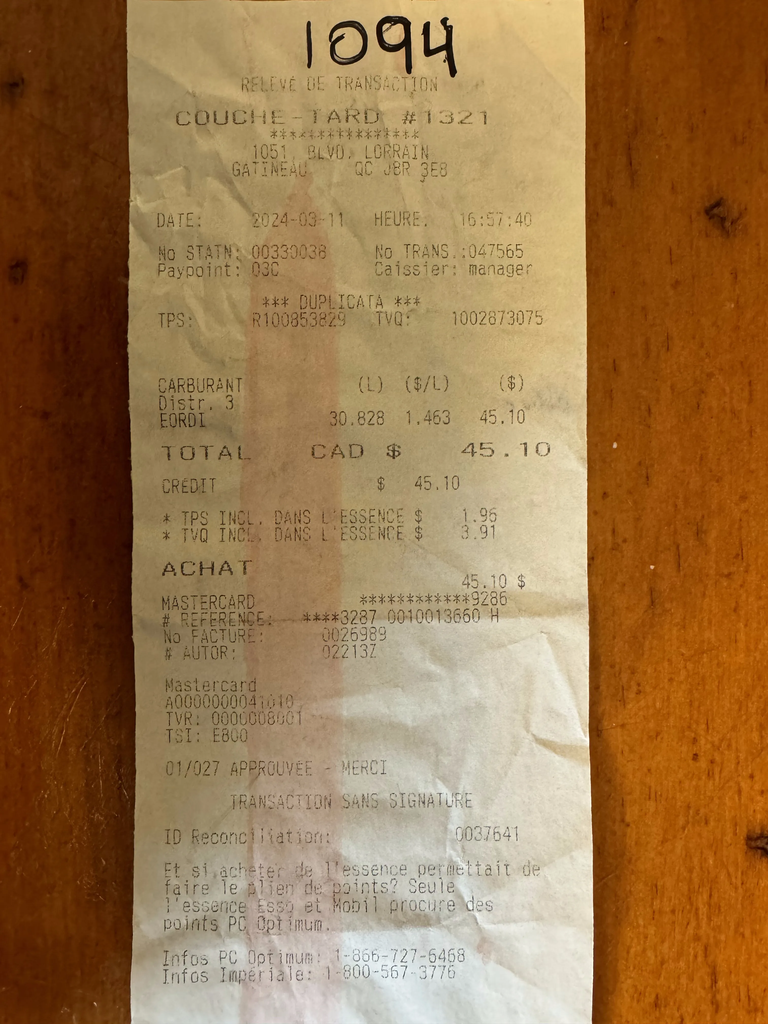

images/receipts/IMG_2163.jpg

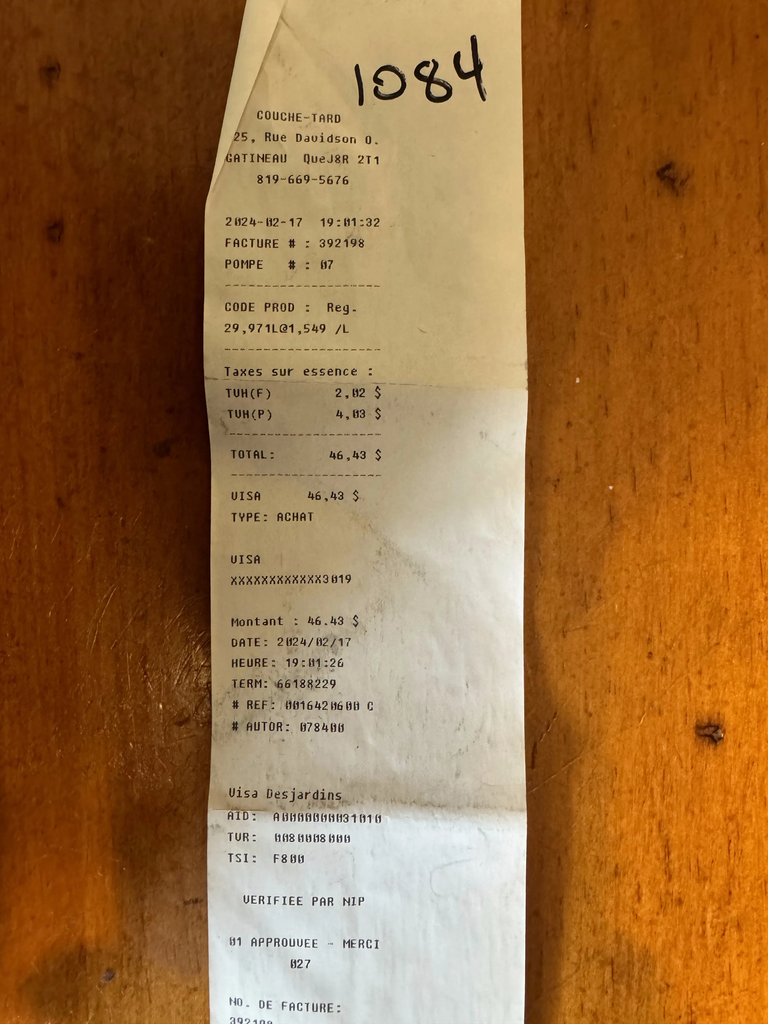

images/receipts/IMG_2166.jpg

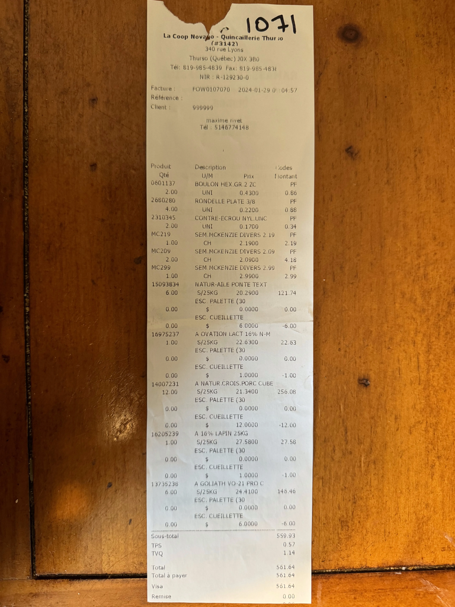

```python
pxt.drop_dir('tuto', force=True)
pxt.create_dir('tuto')

t = pxt.create_table('tuto.receipts',{
        'receipt_path': pxt.type_system.StringType(nullable=False),
        'receipt_image': pxt.Image
    },
    primary_key = 'receipt_path'
)

for p in Path('images/receipts').glob('*.jpg'):
    t.insert(receipt_path=str(p) ,receipt_image=str(p))

t.show(n=3)
```

### Turning or extraction into a Function

Here I have just gathered all the format, llm calling and parsing that we did above into one code chunk to create `extract_totals`, a function able to take in a pillow image and output a json with validated extracted data

```python
class ReceiptTotals(BaseModel):
    before_tax_total: Optional[float] = None
    after_tax_total:  Optional[float] = None

    @field_validator("*", mode="before")
    def _clean(cls, v):
        if v in (None, ""):
            return None
        cleaned = re.sub(r"[^\d.]", "", str(v))
        return float(cleaned) if cleaned else None

def extract_totals(img: Image.Image) -> Dict[str, float]:
    """
    Extract the before-tax and after-tax totals from an receipt image.

    Parameters
    ----------
    img : PIL.Image.Image
        The receipt image (already decoded).

    Returns
    -------
    dict
        Keys: ``before_tax_total``, ``after_tax_total`` (as floats).
    """
    # --- 1. Encode image ---
    buf = io.BytesIO()
    img.convert("RGB").save(buf, format="JPEG", quality=95)
    b64 = base64.b64encode(buf.getvalue()).decode()

    # --- 2. Prompt ---
    prompt = (
        "Extract the after-tax total and the before-tax total from the receipt.\n"
        "Return the values inside these XML tags:\n"
        "<before_tax_total>VALUE</before_tax_total>\n"
        "<after_tax_total>VALUE</after_tax_total>"
    )

    # --- 3. LLM call via LiteLLM ---
    response = litellm.completion(
        model="groq/meta-llama/llama-4-scout-17b-16e-instruct",
        messages=[{
            "role": "user",
            "content": [
                {"type": "text", "text": prompt},
                {"type": "image_url", "image_url": {
                    "url": f"data:…"
                }}
            ]
        }],
        temperature=0
    )

    # --- 4. Parse & validate ---
    raw = response.choices[0]["message"]["content"]
    before = re.search(r"<before_tax_total>(.*?)</before_tax_total>", raw).group(1)
    after  = re.search(r"<after_tax_total>(.*?)</after_tax_total>", raw).group(1)
    return ReceiptTotals(before_tax_total=before, after_tax_total=after).model_dump()
```

```python
extract_totals(Image.open("images/receipts/IMG_2167.jpg"))
```

```
{'before_tax_total': 88.74, 'after_tax_total': 99.3}
```

[output not shown]

### Applying Extraction to All Receipts

Great now let’s turn that function into a user-defined function in pixeltable and apply is to all our images in the table.

```python
@pxt.udf
def extract_totals_udf(img: Image.Image) -> Dict[str, float]:
    return extract_totals(img)

t.add_computed_column(extraction = extract_totals_udf(t.receipt_image))
```

receipt_path

receipt_image

extraction

images/receipts/IMG_2160.jpg

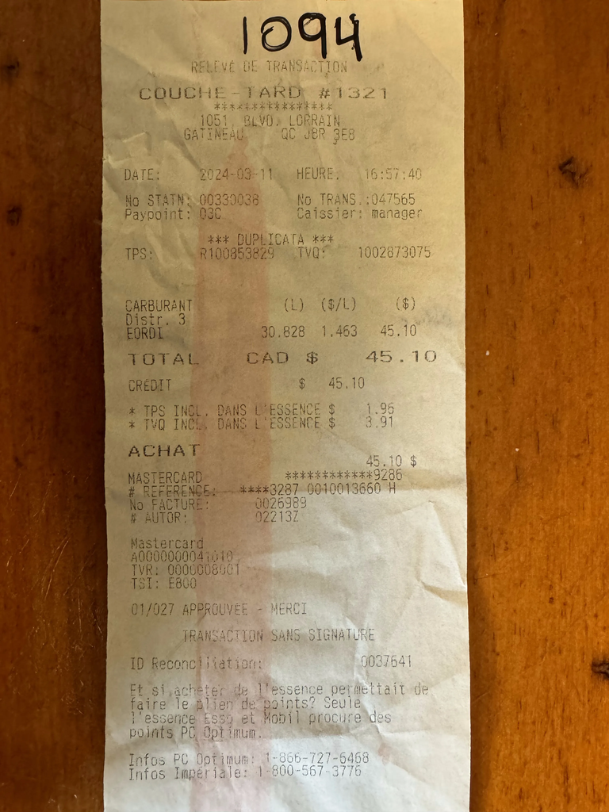

{"after_tax_total": 45.1, "before_tax_total": 39.19}

images/receipts/IMG_2163.jpg

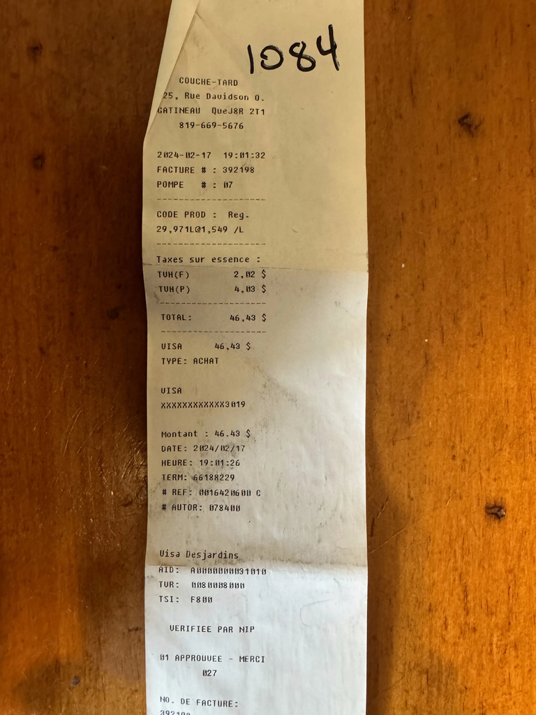

{"after_tax_total": 46.43, "before_tax_total": 39.58}

images/receipts/IMG_2166.jpg

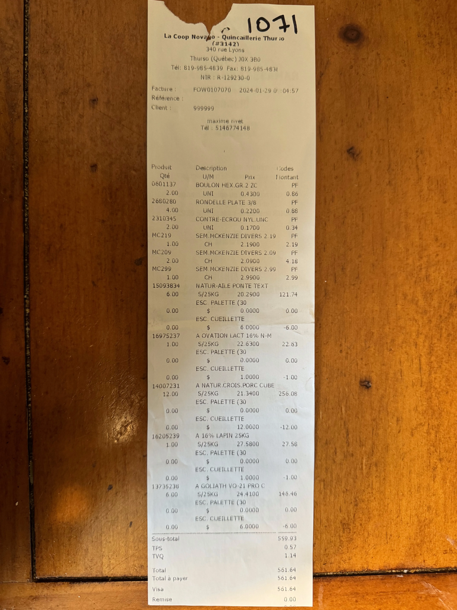

{"after_tax_total": 561.64, "before_tax_total": 559.93}

### Creating and Save the GoldSet

Awesome! The extraction worked, let’s do the same for the evaluation. We will have a column `is_same`.

```python
t.add_column(ground_truth = pxt.Json)
updates = [
    {'receipt_path': 'images/receipts/IMG_2160.jpg', 'ground_truth': {'before_tax_total': 39.23, 'after_tax_total': 45.1}},
    {'receipt_path': 'images/receipts/IMG_2161.jpg', 'ground_truth': {'before_tax_total': 82.74, 'after_tax_total': 95.13}},
    {'receipt_path': 'images/receipts/IMG_2162.jpg', 'ground_truth': {'before_tax_total': 54.63, 'after_tax_total': 62.81}},
    {'receipt_path': 'images/receipts/IMG_2163.jpg', 'ground_truth': {'before_tax_total': 40.38, 'after_tax_total': 46.43}},
    {'receipt_path': 'images/receipts/IMG_2164.jpg', 'ground_truth': {'before_tax_total': 17.39, 'after_tax_total': 20.00}},
    {'receipt_path': 'images/receipts/IMG_2165.jpg', 'ground_truth': {'before_tax_total': 42.8, 'after_tax_total': 49.21}},
    {'receipt_path': 'images/receipts/IMG_2166.jpg', 'ground_truth': {'before_tax_total': 559.93, 'after_tax_total': 561.64}},
    {'receipt_path': 'images/receipts/IMG_2167.jpg', 'ground_truth': {'before_tax_total': 77.18, 'after_tax_total': 88.74}},
    {'receipt_path': 'images/receipts/IMG_2168.jpg', 'ground_truth': {'before_tax_total': 53.06, 'after_tax_total': 61.00}},
    {'receipt_path': 'images/receipts/IMG_2169.jpg', 'ground_truth': {'before_tax_total': None, 'after_tax_total': 12.64}}
]
t.batch_update(updates)
```

```
Added 10 column values with 0 errors.
Inserting rows into `receipts`: 0 rows [00:00, ? rows/s]Inserting rows into `receipts`: 10 rows [00:00, 2023.20 rows/s]
```

```
10 rows updated.
```

```python
@pxt.udf
def metric_udf(gt: dict, pred: dict) -> float:
    return metric(ReceiptTotals(**gt), ReceiptTotals(**pred))
```

```python
t.add_computed_column(is_same = metric_udf(t.ground_truth, t.extraction))
t.select(
    t.ground_truth.before_tax_total,
    t.extraction.before_tax_total,
    t.ground_truth.after_tax_total,
    t.extraction.after_tax_total,
    t.is_same
).head()
```

```
Added 10 column values with 0 errors.
```

| groundtruth_beforetaxtotal | extraction_beforetaxtotal | groundtruth_aftertaxtotal | extraction_aftertaxtotal | is_same |
| --- | --- | --- | --- | --- |
| 39.23 | 39.19 | 45.1 | 45.1 | 0. |
| 40.38 | 39.58 | 46.43 | 46.43 | 0. |
| 559.93 | 559.93 | 561.64 | 561.64 | 1. |
| 77.18 | 88.74 | 88.74 | 99.3 | 0. |
| NaN | 2.32 | 12.64 | 2.64 | 0. |
| 54.63 | 61.46 | 62.81 | 62.81 | 0. |
| 42.8 | 49.21 | 49.21 | 51.62 | 0. |
| 17.39 | 20. | 20. | 22.61 | 0. |
| 53.06 | 61. | 61. | 61. | 0. |
| 82.74 | 85. | 95.13 | 95.13 | 0. |

Well that is a pretty bad performance!!! Let’s see how much better we can make it. but first let’s recap.

We first, saw how to make llm calls with image using the openai-like completion api through litellm. Then we turned that into a function which we applied to 10 images using computed columns in a pixeltable, the advantage of the computed column is that if we add an 11th image all the computed columns we but triggered to compute automatically.

Like this:

```python
t.insert(receipt_path = "images/extra_receipt.jpg",
         receipt_image = "images/extra_receipt.jpg",
         ground_truth = {
            'before_tax_total': 651.86,
            'after_tax_total': 749.47}
)
```

receipt_image

extraction

is_same

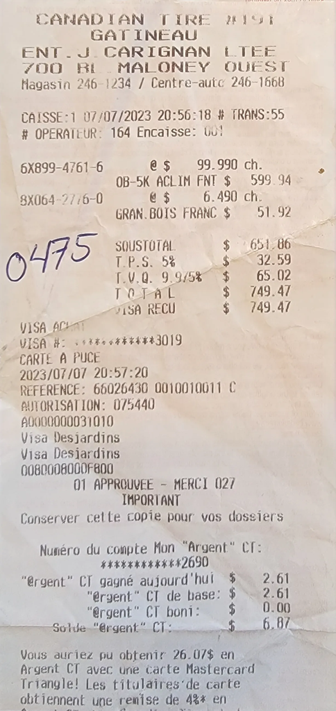

{"after_tax_total": 749.47, "before_tax_total": 651.86}

1.

```python
t.select(t.receipt_image, t.extraction, t.is_same).tail(1)
```

As we invest more and more into the pipeline this is more and more powerful an worth it!

## Building Our Own Prompt Optimizer

At this point, we have a ‘working’ pipeline that scores 11 receipts with an LLM and a metric that tells us how good the current prompt is. Our baseline score is quite low (as we saw, 2/11 get both before and after tax correct), and what we **don’t** have is an automated way to find a better prompt.

How do we automate this? We don’t need to guess. We can look directly at the source code of DSPy’s state-of-the-art optimizers, to see the strategy they employ.

### The MIPROv2 Strategy

MIPROv2’s core idea is to use a powerful LLM (the “optimizer LLM”) to propose improvements to the prompts used by your AI system (the “task LLM”). It also simultaneously searches for the best few-shot examples to include in the context. It then uses Bayesian Optimization to efficiently search this joint space (Instructions x Few-Shot Examples).

The mechanism responsible for proposing new instructions is called the `GroundedProposer`. To generate effective proposals, the optimizer LLM needs context. Looking at the arguments and logic within the `GroundedProposer` implementation (provided in the DSPy source code), we can see it gathers several crucial pieces of information:

1. **Program Awareness (`program_aware`)**: Remarkably, MIPROv2 reads the source code of your AI pipeline. It summarizes the overall goal of the program (`program_description`) and the specific role of the module (prompt) being optimized (`module_description`).
2. **Data Awareness (`use_dataset_summary`)**: MIPROv2 analyzes the training data and creates a summary of the dataset (`dataset_description`). This helps the optimizer LLM understand the overall nature of the inputs.
3. **Grounded Examples (`use_task_demos`)**: It selects specific input/output examples (`task_demos`) from the dataset. These often include examples where the current prompt is failing, grounding the optimization in real data.
4. **History Awareness (`use_instruct_history`)**: It reviews previous prompt attempts and their associated scores (`previous_instructions`), allowing the optimizer LLM to learn from past successes and failures.
5. **Exploration Strategies (`use_tip`)**: It sometimes adds randomized “tips” to the optimizer LLM (e.g., “Be creative,” “Keep it concise”) to explore different styles of instructions.

MIPROv2 combines all this information into a comprehensive “meta-prompt” to generate new candidate instructions.

### Our Simplified Implementation

To keep things manageable and understand the core mechanism, we will build a simplified version of this process by hand. We will focus primarily on **(3) Grounded Examples** (specifically, the receipts where our current prompt failed) and a simplified version of **(1) Program Awareness** (by explicitly stating the task goal). We will skip the automated summaries, history tracking, few-shot optimization, and Bayesian search for now.

We will create a loop that does the following:

1. **Identify Errors**: Find the receipts where `is_same` is 0.0.
2. **Create Context**: Use these errors (Grounded Examples) and the task goal (Program Awareness) as input for the prompt generator.
3. **Generate New Instructions**: Use an LLM and a meta-prompt derived from the concepts in MIPROv2 to propose a new instruction.
4. **Evaluate and Select**: Apply the new instruction, calculate the score, and keep the best prompt (a simple greedy search).

When we’re done with this section, you will have a simplified, copy-pastable implementation of DSPy’s instruction generation strategy, and hopefully, watch the performance of your LLM go up in minutes!

### The Prompt Generator (The Optimizer LLM)

We need a meta-prompt to ask the optimizer LLM to generate a better instruction. We will adapt the structure used internally by MIPROv2. In the source code, the internal mechanism (`GenerateModuleInstruction`) defines the fields for the meta-prompt, utilizing the context gathered by the `GroundedProposer`.

We will adapt this structure into a standard text prompt, explicitly mapping our manual inputs to the corresponding concepts used in the DSPy source code:

```python
PROMPT_GENERATOR_TEMPLATE = """
You are an expert prompt optimizer. Use the information below to learn about a task that we are trying to solve using calls to an LM, then generate a new instruction that will be used to prompt a Language Model to better solve the task.

# Corresponds to program_description in DSPy
[PROGRAM SUMMARY]
The goal of the task is to extract the 'before tax total' and the 'after tax total' from images of receipts. The output must be parsable using specific XML tags.

# Corresponds to basic_instruction in DSPy
[CURRENT INSTRUCTION]
<current_prompt>
{current_prompt}
</current_prompt>

# Corresponds to task_demos in DSPy (focusing on failures)
[TASK DEMOS - FAILURES]
The current prompt fails on several examples. Here are the details (Ground Truth vs. Prediction):
<failures>
{failures}
</failures>

Analyze these failures. Why did the extraction likely fail based on the current instruction and the demos?
Propose a new, improved instruction prompt that addresses these failures.

IMPORTANT: The new prompt MUST ensure the model outputs the results in the following XML tags:
<before_tax_total>VALUE</before_tax_total>
<after_tax_total>VALUE</after_tax_total>

# Corresponds to proposed_instruction (the output field) in DSPy
[PROPOSED INSTRUCTION]
Provide your improved instruction prompt in the <proposed_prompt> tag.
"""
```

By using this structure, we are leveraging the proven methodology of MIPROv2, even in our manual implementation.

### Implementing the Optimization Loop

Now let’s implement the optimization logic. We need a utility to format the failures so we can inject them into the `PROMPT_GENERATOR_TEMPLATE`.

```python
@pxt.uda
class format_failures(func.Aggregator):
    """
    Aggregates failure cases by formatting them into a single string.
    Processes all rows from the input table.
    """
    def __init__(self):
        self.failures: list[str] = []
        self.example_num = 0

    def update(self, ground_truth: Optional[str], extraction: Optional[str]) -> None:
        # Called for each row; formats and adds the failure to the list
        self.example_num += 1
        failure_entry = (
            f"Example {self.example_num}:\n"
            f"  Ground Truth: {ground_truth}\n"
            f"  Prediction: {extraction}\n\n"
        )
        self.failures.append(failure_entry)

    def value(self) -> str:
        # Returns the final, combined string
        return "".join(self.failures)
```

And now the main optimization function. This function will take the current prompt, identify failures using our Pixeltable data, call the LLM to propose a new prompt, and return the raw response from the optimizer LLM.

```python
import litellm

def propose_new_prompt(current_prompt, table, failures_df):
    """Proposes a new prompt using an LLM optimizer."""

    # 1. Identify Errors
    # We use Pixeltable's filter mechanism (where) to find rows where the metric failed.

    if failures_df.count() == 0:
        print("No failures found. Optimization complete.")
        return None

    # 2. Format Failures
    failures_str = failures_df.select(format_failures(table.ground_truth, table.extraction)).collect()[0]['format_failures']

    images = []
    for img in failures_df.collect()["receipt_image"]:
        buf = io.BytesIO()
        img.convert("RGB").save(buf, format="JPEG", quality=95)
        b64 = base64.b64encode(buf.getvalue()).decode()
        images.append({"type": "image_url", "image_url": {
                    "url": f"data:…"
                }})
    # 3. Generate New Instruction
    prompt = PROMPT_GENERATOR_TEMPLATE.format(
        current_prompt=current_prompt,
        failures=failures_str
    )
    print("Calling LLM to propose a new prompt...")
    # MIPROv2 adds slight variation to temperature (T + epsilon) for exploration
    response = litellm.completion(
        model="openrouter/google/gemini-2.5-pro", # We use a 'smarter' llm for optimization
        messages=[{"role": "user", "content": [
                {"type": "text", "text": prompt},
                *images[:3]
            ]}],
        temperature=0 # for reproducibility
    )

    return response.choices[0]["message"]["content"]
```

### Running the Optimizer (Iteration 1)

Let’s run the first iteration of the optimization.

First, we retrieve our initial prompt.

```python
initial_prompt = (
"Extract the after-tax total and the before-tax total from the receipt.\n"
"Return the values inside these XML tags:\n"
"<before_tax_total>VALUE</before_tax_total>\n"
"<after_tax_total>VALUE</after_tax_total>"
)
```

Let’s check our initial score before optimizing.

````markdown
```{python}
t.select(pxt.functions.mean(t.is_same)).collect()
```
````

A score of around 18% (depending on the exact LLM runs) is quite poor. Let’s see if the optimizer can help.

````markdown
```{python}
optimization_response = propose_new_prompt(initial_prompt, t, t.where(t.is_same == 0.0))
optimization_response
```
````

The LLM analyzed the failures (the `task_demos`)—e.g., cases where the model confused the before and after tax totals, or failed to calculate the before-tax amount when it wasn’t explicit—and proposed a new prompt. Let’s extract it from the response.

````markdown
```{python}
import re
proposed_prompt_match = re.search(r"<proposed_prompt>(.*?)</proposed_prompt>", optimization_response, re.DOTALL)

if proposed_prompt_match:
    proposed_prompt_v1 = proposed_prompt_match.group(1).strip()
    print(proposed_prompt_v1)
else:
    print("Could not extract proposed prompt.")
    # Fallback in case the optimizer fails to follow the output format
    proposed_prompt_v1 = initial_prompt
```
````

### Evaluating the New Prompt

Now the crucial step: does this new prompt actually perform better?

To evaluate it, we need to update our extraction function so that it accepts the prompt as an argument, rather than having it hardcoded.

**Refactoring: Making the Prompt Flexible**

````markdown
```{python}
from PIL import Image
from typing import Dict
import base64, io

def extract_totals_with_prompt(img: Image.Image, prompt: str) -> Dict[str, float]:
    """Extracts totals using a specified prompt."""
    # --- 1. Encode image --- (Same as before)
    buf = io.BytesIO()
    img.convert("RGB").save(buf, format="JPEG", quality=95)
    b64 = base64.b64encode(buf.getvalue()).decode()

    # --- 2. LLM call --- (Using the provided prompt)
    try:
        response = litellm.completion(
            model="groq/meta-llama/llama-4-maverick-17b-128e-instruct",
            messages=[{
                "role": "user",
                "content": [
                    {"type": "text", "text": prompt},
                    {"type": "image_url", "image_url": {
                        "url": f"data:…"
                    }}
                ]
            }],
            temperature=0 # Keep temperature 0 for evaluation
        )
        raw = response.choices[0]["message"]["content"]

        # --- 3. Parse & validate ---
        # We need slightly more robust regex in case the LLM adds extra text
        before_match = re.search(r"<before_tax_total>(.*?)</before_tax_total>", raw, re.DOTALL)
        after_match = re.search(r"<after_tax_total>(.*?)</after_tax_total>", raw, re.DOTALL)

        before = before_match.group(1).strip() if before_match else None
        after = after_match.group(1).strip() if after_match else None

        # Use Pydantic for validation and cleaning
        return ReceiptTotals(before_tax_total=before, after_tax_total=after).model_dump()

    except Exception as e:
        # print(f"Error during extraction or parsing: {e}")
        # Return default empty structure on failure
        return ReceiptTotals().model_dump()
```
````

Now we can evaluate this new prompt across the dataset.

````markdown
```{python}
@pxt.udf
def extract_totals_v1_udf(img: Image.Image) -> Dict[str, float]:
    return extract_totals_with_prompt(img, proposed_prompt_v1)

t.add_computed_column(extraction_v1 = extract_totals_v1_udf(t.receipt_image))
t.show(3)
```
````

````markdown
```{python}
t.add_computed_column(is_same_v1 = metric_udf(t.ground_truth, t.extraction_v1))
t.select(pxt.functions.mean(t.is_same_v1)).collect()
```
````

### Running the Optimizer (Iteration 2)

Can we do even better? Let’s run another iteration. To do this, we first need to update our Pixeltable with the results of the V1 prompt so the optimizer can analyze the *remaining* failures.

Now we run the optimizer again, starting from the V1 prompt.

````markdown
```{python}
optimization_response_v2 = propose_new_prompt(proposed_prompt_v1, t, t.where(t.is_same_v1 == 0.0))
print(optimization_response_v2)
```
````

Let’s extract the V2 prompt.

````markdown
```{python}
proposed_prompt_match_v2 = re.search(r"<proposed_prompt>(.*?)</proposed_prompt>", optimization_response_v2, re.DOTALL)
proposed_prompt_v2 = proposed_prompt_match_v2.group(1).strip()
print(proposed_prompt_v2)
```
````

The V2 prompt further refined the instructions, specifically addressing the remaining errors identified by the optimizer LLM. It might add emphasis on handling specific tax names, rounding issues, or emphasizing precision in calculation.

Let’s apply and evaluate the V2 prompt.

````markdown
```{python}
@pxt.udf
def extract_totals_v2_udf(img: Image.Image) -> Dict[str, float]:
    return extract_totals_with_prompt(img, proposed_prompt_v2)

t.add_computed_column(extraction_v2 = extract_totals_v2_udf(t.receipt_image))
t.add_computed_column(is_same_v2 = metric_udf(t.ground_truth, t.extraction_v2))
```
````

````markdown
```{python}
t.select(pxt.functions.mean(t.is_same_v2)).collect()
```
````

````markdown
```{python}
t.select(t.is_same, t.is_same_v1, t.is_same_v2).show()
```
````

### Recap of Manual Optimization

We successfully built a simple, prompt optimizer by directly implementing a simplified version of the instruction generation strategy found in DSPy. The key takeaways are:

1. **Grounded Generation**: We are grounding the prompt optimization generation in data. By analyzing specific failures and the goal, the system can self-improve.
2. **The Power of Meta-Prompts**: Using an LLM to optimize the prompt of another LLM is effective.
3. **Iterative Improvement**: Optimization is rarely a one-shot process. The iterative loop of Generate -> Evaluate -> Analyze Failures -> Regenerate will make us climb the hill.

While this manual implementation ‘worked’, it has limitations:

- **It’s Manual and Boilerplate Heavy**: We wrote a lot of code for formatting, API calls, parsing, and managing the data pipeline loop.
- **It’s Simplified**: We only optimized the instructions based on failures. The full MIPROv2 also optimizes few-shot examples, automatically summarizes the dataset and program code, uses history, and leverages randomized tips to inform future proposals (and more!).
- **Simple Search Strategy**: We used a simple for loop. MIPROv2 and many other DSPy optimizers uses Bayesian optimization to search the space of possible prompts much more efficiently.

In the next section, we will see how DSPy streamlines this entire process, making optimization faster, more robust, and requiring significantly less code.

# DSPy’s Prompt Optimization

Finally we are in dspy, the code will be much simpler! First, let’s create a connection. DSPy uses litellm behind the scene so the model string that worked above are the same here. But there is much less boilerplate. For instance, we can create a connection to llama and call it just like that:

````markdown
```{python}
import dspy

lm = dspy.LM("groq/meta-llama/llama-4-scout-17b-16e-instruct")
lm("hello")
```
````

As we discussed above, to optimize a task we need the optimizers to know what our intent is. We mentionned 4 ways to specify intent: 1) by example, with a goldset, 2) by a rubric or judge, 3) by instructions and/or 4) by stating the input/output. Here we will provide example (1), instructions (3), and state the required inputs and outputs (4).

As a reminder out instruction were:

> Extract the after-tax total and the before-tax total from the receipt.

So in dspy, to provide the input, ouptut requirements and the instructions we write a signature. To write a signature we do that:

````markdown
```{python}
from pydantic import BaseModel
from typing import Optional

class ReceiptTotals(BaseModel):
    before_tax_total: Optional[float] = None
    after_tax_total:  Optional[float] = None

class OurIntent(dspy.Signature): #OurIntent can be any name we want
    """
    Extract the after-tax total and the before-tax total from the receipt.
    """
    receipt_image: dspy.Image = dspy.InputField()
    receipt_totals: ReceiptTotals = dspy.OutputField()
```
````

That’s it, see how we reuse the pydantic model `ReceiptTotals` we created above. Now let’s try it out.

First we must turn our signature into what dspy call a ‘program’ and set the language model to use:

````markdown
```{python}
dprogram = dspy.Predict(OurIntent)
dprogram.set_lm(lm)
```
````

Now we can call our program:

````markdown
```{python}
dprogram(receipt_image = dspy.Image.from_file(file_path = "images/receipts/IMG_2160.jpg"))
```
````

That program contains information about the instructions, input/outputs, etc. It uses templates called adapters to turn those into a prompt. At this point in our process dspy has not optimized anything for us it have simply helped us focus only on the part that matters. It was much simpler to get to an llm call then it was before. Let’s now add the base dspy prompt into our pixel table.

````markdown
```{python}
@pxt.udf
def dspy_baseline(img: Image.Image) -> Dict[str, float]:
    return dprogram(receipt_image = dspy.Image.from_PIL(img)).receipt_totals.model_dump()

t.add_computed_column(extraction_dspybase = dspy_baseline(t.receipt_image))
```
````

````markdown
```{python}
t.add_computed_column(is_same_dspybase = metric_udf(t.ground_truth, t.extraction_dspybase))
```
````

````markdown
```{python}
t.select(pxt.functions.mean(t.is_same_dspybase)).collect()
```
````

````markdown
```{python}
t.select(t.is_same, t.is_same_v1, t.is_same_v2, t.is_same_dspybase).show()
```
````

Let’s optimize it now

## DSPy Instruction Optimization

As mentionned previously, dspy can optimize many components of the AI system, now we will focus on optimizing only the instruction, similarly to what we have just done ‘manually’.

The optimizer will need, a trainset, a metric, and a program. We aleary how the program, now we need to reshape our 10 example in dspy object. DSPy wants a list of `dspy.Example` objects. Similarly we will need to adapt the metric to be using the `dspy.Example` object.

### Adjusting for DSPy

Let’s reuse the list of dictionnay that use used at the beginning of the tutorial and reshape it for dspy.

The training set:

````markdown
```{python}
goldset = [
    {'receipt_path': 'images/receipts/IMG_2160.jpg', 'ground_truth': {'before_tax_total': 39.23, 'after_tax_total': 45.1}},
    {'receipt_path': 'images/receipts/IMG_2161.jpg', 'ground_truth': {'before_tax_total': 82.74, 'after_tax_total': 95.13}},
    {'receipt_path': 'images/receipts/IMG_2162.jpg', 'ground_truth': {'before_tax_total': 54.63, 'after_tax_total': 62.81}},
    {'receipt_path': 'images/receipts/IMG_2163.jpg', 'ground_truth': {'before_tax_total': 40.38, 'after_tax_total': 46.43}},
    {'receipt_path': 'images/receipts/IMG_2164.jpg', 'ground_truth': {'before_tax_total': 17.39, 'after_tax_total': 20.00}},
    {'receipt_path': 'images/receipts/IMG_2165.jpg', 'ground_truth': {'before_tax_total': 42.8, 'after_tax_total': 49.21}},
    {'receipt_path': 'images/receipts/IMG_2166.jpg', 'ground_truth': {'before_tax_total': 559.93, 'after_tax_total': 561.64}},
    {'receipt_path': 'images/receipts/IMG_2167.jpg', 'ground_truth': {'before_tax_total': 77.18, 'after_tax_total': 88.74}},
    {'receipt_path': 'images/receipts/IMG_2168.jpg', 'ground_truth': {'before_tax_total': 53.06, 'after_tax_total': 61.00}},
    {'receipt_path': 'images/receipts/IMG_2169.jpg', 'ground_truth': {'before_tax_total': None, 'after_tax_total': 12.64}}
]
trainset = [dspy.Example(
    receipt_image = dspy.Image.from_file(i["receipt_path"]),
    receipt_totals = ReceiptTotals(
        before_tax_total = i["ground_truth"]["before_tax_total"],
        after_tax_total = i["ground_truth"]["after_tax_total"]
        )
    ).with_inputs("receipt_image") for i in goldset
]
```
````

now for the metric, this is what we have beend working with so far:

````markdown
```{python}
def metric(ground_truth, pred):
    is_btax_same = ground_truth.before_tax_total == pred.before_tax_total
    is_atax_same = ground_truth.after_tax_total == pred.after_tax_total
    return float(is_btax_same and is_atax_same)
```
````

and this is what dspy expects:

````markdown
```{python}
def metric_dspy(example, pred, trace=None):
    is_btax_same = example.receipt_totals.before_tax_total == pred.receipt_totals.before_tax_total
    is_atax_same = example.receipt_totals.after_tax_total == pred.receipt_totals.after_tax_total
    return float(is_btax_same and is_atax_same)
```
````

### Optimizing

#### Instructions

````markdown
```{python}
teacherp = dprogram.deepcopy()
teacherp.set_lm(lm = dspy.LM("openrouter/google/gemini-2.5-pro"))
optimizer = dspy.MIPROv2(
    metric_dspy,
    max_bootstrapped_demos = 0,
    max_labeled_demos = 0,
    prompt_model=dspy.LM("openrouter/google/gemini-2.5-pro"),
    auto = "medium")
dprogram_optimized = optimizer.compile(dprogram, trainset=trainset, requires_permission_to_run = False, teacher = teacherp)
```
````

````markdown
```{python}
dprogram_optimized.inspect_history()
```
````

````markdown
```{python}
dprogram_optimized(receipt_image = dspy.Image.from_file(file_path = "images/receipts/IMG_2160.jpg"))
```
````

````markdown
```{python}
@pxt.udf
def dspy_optimized(img: Image.Image) -> Dict[str, float]:
    return dprogram_optimized(receipt_image = dspy.Image.from_PIL(img)).receipt_totals.model_dump()

t.add_computed_column(extraction_dspyopt = dspy_optimized(t.receipt_image))
```
````

````markdown
```{python}
t.add_computed_column(is_same_dspyopt = metric_udf(t.ground_truth, t.extraction_dspyopt))
```
````

````markdown
```{python}
t.select(pxt.functions.mean(t.is_same_dspyopt)).collect()
```
````

````markdown
```{python}
t.select(t.is_same, t.is_same_v1, t.is_same_v2, t.is_same_dspybase, t.is_same_dspyopt).show()
```
````

````markdown
```{python}
dprogram_optimized.save("dspy_optimized.json")
```
````